# Turnstile Analysis

Este notebook se crea con el fin de mantener ordenado la investigación relacionada con el impacto que tiene el uso de torniquete mariposa en la operación de buses de Transantiago. En particular este script contiene el proceso de manejo de información de la base de datos de fiscalización (ya procesada), el análisis descriptivo de dicha base de datos y la construcción de modelos de tiempos medios de viaje.

A continuación se crean funciones necesarias a lo largo del script (no se muestra código ni output asociado)

Getting and editing signals dataframe

```r
#Options
options(max.print=10000)

#Setting working space
setwd("/Users/diego/Desktop/Evasion/01_analisis/03_datos/04_NI/")
signals <- read.csv(file = "NI.csv", header = TRUE, sep = ";")

#Editing signals dataframe
signals$ROUTE_NAME <- as.character(signals$ROUTE_NAME)
signals$ROUTE_NAME <- gsub(" ","",signals$ROUTE_NAME)
signals$ROUTE_NAME <- toupper(signals$ROUTE_NAME)
signals$Desde <- as.Date(as.character(signals$Desde))
signals$Hasta <- as.Date(as.character(signals$Hasta))
signals <- signals[!duplicated(signals),]
#duplicados_signal <- signals[duplicated(signals) | duplicated(signals, fromLast = TRUE),]
```

Getting and editing variables dataframe

```r
#Setting working space
setwd("/Users/diego/Desktop/Evasion/01_analisis/03_datos/07_Bases_consolidadas/")

#Reading input files
dataframe <- read.csv(file = "base_modelo.csv", header = TRUE, sep = ";")

#Editing expedition dataframe
dataframe$Código.TCAD <- as.character(dataframe$Código.TCAD)
dataframe$Código.TCAD <- gsub(" ","",dataframe$Código.TCAD)
dataframe$Código.TCAD <- toupper(dataframe$Código.TCAD)
dataframe$Fecha <- as.Date(as.character(dataframe$Fecha))
names(dataframe)[50] <- "CodTCAD"

#Merge between route and number of signals by date
database <- sqldf('SELECT dataframe.*, signals.*
                  FROM dataframe
                  LEFT JOIN signals
                  ON dataframe.CodTCAD = signals.ROUTE_NAME
                  AND dataframe.Fecha BETWEEN signals.Desde AND signals.Hasta')

#Getting NAs
ind_na <- which(is.na(database$NI))
test_na <- database[ind_na,]

#Deleting NAs
database <- database[-ind_na,]
```

# Data Analysis

### Análisis de variables

```
##      texp_s         largo_m      demanda_total    evasion_total
##  Min.   :  540   Min.   : 3340   Min.   :  0.00   Min.   :  0.00
##  1st Qu.: 1620   1st Qu.: 8940   1st Qu.: 23.00   1st Qu.:  3.00
##  Median : 2460   Median :13570   Median : 42.00   Median :  9.00
##  Mean   : 2999   Mean   :15462   Mean   : 59.22   Mean   : 17.82
##  3rd Qu.: 3900   3rd Qu.:20230   3rd Qu.: 79.50   3rd Qu.: 24.00
##  Max.   :11820   Max.   :49580   Max.   :479.00   Max.   :197.00
##   detenciones          NI
##  Min.   : 1.00   Min.   :  0.00
##  1st Qu.:11.00   1st Qu.: 14.00
##  Median :17.00   Median : 22.00
##  Mean   :19.97   Mean   : 34.21
##  3rd Qu.:25.00   3rd Qu.: 43.00
##  Max.   :92.00   Max.   :151.00
```

Número de expediciones sin torniquete:

```
## [1] 3127
```

Número de expediciones con torniquete mariposa:

```
## [1] 664
```

Número de expediciones con torniquete mariposa en periodo punta:

```
## [1] 223
```

Número de expediciones con torniquete de tres brazos:

```
## [1] 512
```

### Histograma tiempos de expedicion:

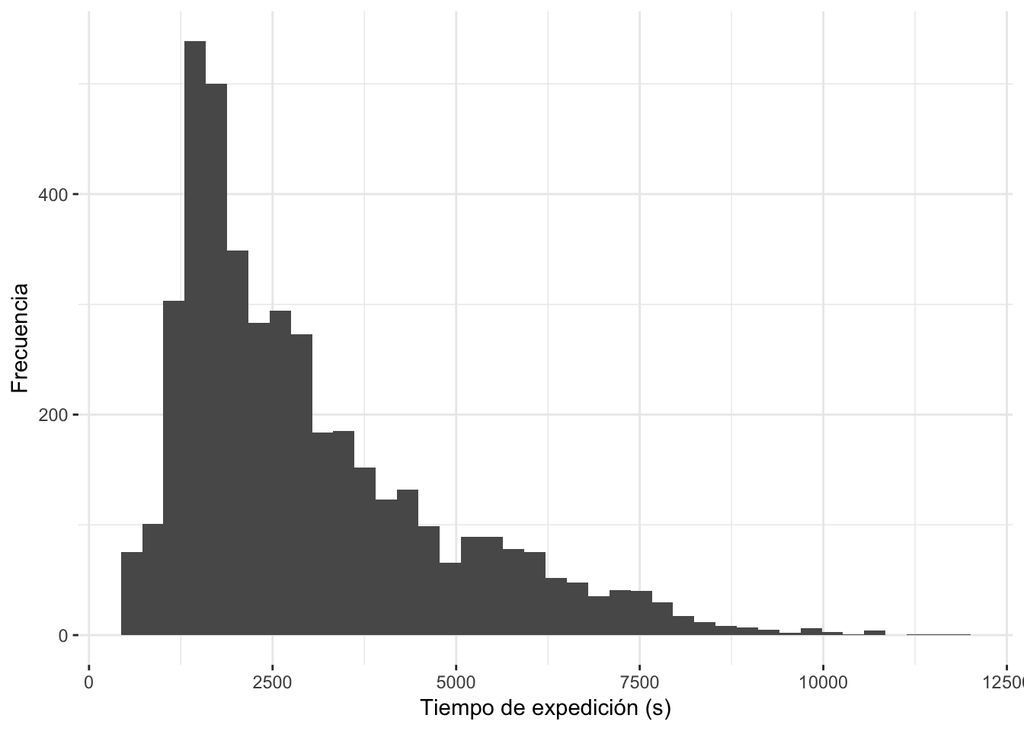

### Histograma y boxplot del largo de los recorridos:

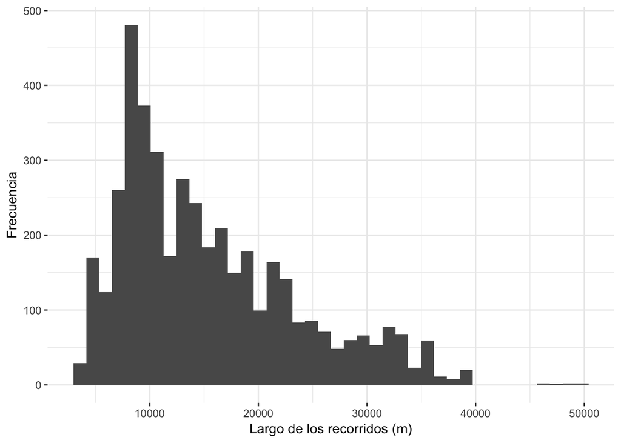

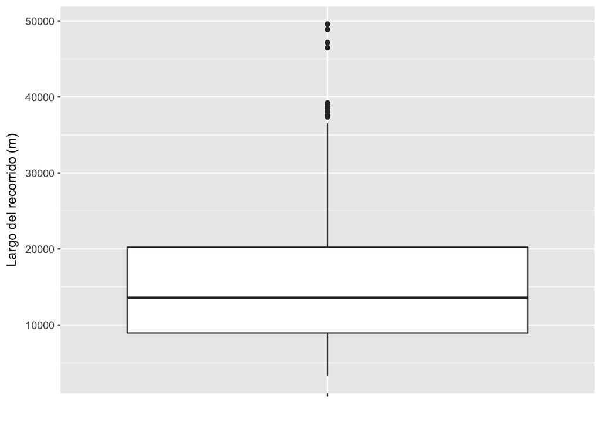

```
## $stats
## [1]  3340  8940 13570 20230 36530
##
## $n
## [1] 4303
##
## $conf
## [1] 13298.06 13841.94
##
## $out
##  [1] 38030 38210 37590 39030 38650 39060 38650 38650 38650 38650 38650
## [12] 38650 39210 37590 37370 39165 39030 39030 38440 38570 38570 38570
## [23] 39030 47150 49580 49580 46460 46460 48880 48880 38020 38650 39165
## [34] 38020 38650
```

# Travel time models

A continuación se crean modelos econométricos para estimar el tiempo medio de viaje controlando por el efecto de distintas variabless, como el uso de torniquete mariposa.

### Modelo 1

El primer modelo es un modelo simple que incluye el largo del recorrido, el número de detenciones, la demanda total, y el número de intersecciones.

$T = c + t_{L} \cdot L + t_{s}\cdot S + t_{Y}\cdot Y + t_{I}\cdot N_{I}$

```
##
## Call:
## lm(formula = as.formula("texp~."), data = data.all)
##
## Residuals:
##     Min      1Q  Median      3Q     Max
## -2307.8  -292.7   -28.9   235.8  6717.8
##
## Coefficients:
##             Estimate Std. Error t value Pr(>|t|)
## (Intercept) -11.4868    21.8653  -0.525 0.599372
## largo       140.9272     2.1380  65.914  < 2e-16 ***
## detenciones   4.2239     1.1595   3.643 0.000273 ***
## Y             6.1093     0.2953  20.689  < 2e-16 ***
## NI           11.2503     0.5404  20.818  < 2e-16 ***
## ---
## Signif. codes:  0 '***' 0.001 '**' 0.01 '*' 0.05 '.' 0.1 ' ' 1
##
## Residual standard error: 596.2 on 4298 degrees of freedom
## Multiple R-squared:  0.8937, Adjusted R-squared:  0.8936
## F-statistic:  9031 on 4 and 4298 DF,  p-value: < 2.2e-16
```

### Modelo 2

El segundo modelo corresponde a una extensión del primero, pero considerando una dummy para el número de intersecciones semaforizadas que sea uno en el caso que la expedición se haga en un periodo punta (punta mañana o tarde). Dando cuenta de la programación más favorable que se puede encontrar en dichos periodos o también de congestión por sobresaturación en algunos casos.

$T = c + t_{L} \cdot L + t_{s}\cdot S + t_{Y}\cdot Y + t_{I}\cdot N_{I} + t_{peak}^{I} \cdot \tau_{peak} \cdot N_{I}$

```
##
## Call:
## lm(formula = as.formula("texp~."), data = data.all)
##
## Residuals:
##     Min      1Q  Median      3Q     Max
## -2623.6  -282.8   -23.0   240.4  6825.3
##
## Coefficients:
##             Estimate Std. Error t value Pr(>|t|)
## (Intercept) -19.5896    21.5722  -0.908    0.364
## largo       142.8240     2.1151  67.527  < 2e-16 ***
## detenciones   5.5348     1.1493   4.816 1.52e-06 ***
## Y             5.1648     0.3033  17.028  < 2e-16 ***
## NI            9.8572     0.5474  18.008  < 2e-16 ***
## NI_peak       4.7053     0.4232  11.118  < 2e-16 ***
## ---
## Signif. codes:  0 '***' 0.001 '**' 0.01 '*' 0.05 '.' 0.1 ' ' 1
##
## Residual standard error: 587.8 on 4297 degrees of freedom
## Multiple R-squared:  0.8966, Adjusted R-squared:  0.8965
## F-statistic:  7455 on 5 and 4297 DF,  p-value: < 2.2e-16
```

### Modelo 3

En el siguiente modelo agrega una variable dummy por la demanda total de la expedición. Esta variable será uno en el caso que el viaje se haga en un periodo punta (punta mañana o punta tarde)

$T = c + t_{L} \cdot L + t_{s}\cdot S + t_{Y}\cdot Y + t_{Y}^{peak} \cdot \tau_{peak} \cdot Y + t_{I}\cdot N_{I} + t_{peak}^{I} \cdot \tau_{peak} \cdot N_{I}$

```
##
## Call:
## lm(formula = as.formula("texp~."), data = data.all)
##
## Residuals:
##     Min      1Q  Median      3Q     Max
## -2604.7  -282.9   -23.2   241.8  6773.6
##
## Coefficients:
##             Estimate Std. Error t value Pr(>|t|)
## (Intercept) -22.3345    21.5339  -1.037    0.300
## largo       143.1538     2.1118  67.789  < 2e-16 ***
## detenciones   5.9164     1.1500   5.145 2.80e-07 ***
## Y             4.0575     0.3917  10.359  < 2e-16 ***
## Y_Peak        1.9870     0.4461   4.454 8.65e-06 ***
## NI           11.0678     0.6101  18.141  < 2e-16 ***
## NI_peak       1.7276     0.7908   2.185    0.029 *
## ---
## Signif. codes:  0 '***' 0.001 '**' 0.01 '*' 0.05 '.' 0.1 ' ' 1
##
## Residual standard error: 586.6 on 4296 degrees of freedom
## Multiple R-squared:  0.8971, Adjusted R-squared:  0.897
## F-statistic:  6243 on 6 and 4296 DF,  p-value: < 2.2e-16
```

### Modelo 4

En el siguiente modelo se saca la componente extra de demora por intersecciones semaforizadas y se agrega una variable de demanda total en presencia de torniquete mariposa.

```
##
## Call:
## lm(formula = as.formula("texp~."), data = data.all)
##
## Residuals:
##     Min      1Q  Median      3Q     Max
## -2812.4  -283.7   -21.3   232.1  6740.2
##
## Coefficients:
##             Estimate Std. Error t value Pr(>|t|)
## (Intercept) -36.5618    21.4158  -1.707   0.0878 .
## largo       142.2484     2.0964  67.853  < 2e-16 ***
## detenciones   6.0519     1.1406   5.306 1.18e-07 ***
## Y             3.5098     0.3530   9.943  < 2e-16 ***
## Y_Peak        2.6837     0.2367  11.336  < 2e-16 ***
## Y_Marip       3.7800     0.4324   8.742  < 2e-16 ***
## NI           12.1795     0.5314  22.919  < 2e-16 ***
## ---
## Signif. codes:  0 '***' 0.001 '**' 0.01 '*' 0.05 '.' 0.1 ' ' 1
##
## Residual standard error: 581.7 on 4296 degrees of freedom
## Multiple R-squared:  0.8988, Adjusted R-squared:  0.8987
## F-statistic:  6359 on 6 and 4296 DF,  p-value: < 2.2e-16
```

### Modelo 5

El siguiente modelo es el modelo 4, pero desagregando la demanda por puerta de acceso.

```
##
## Call:
## lm(formula = as.formula("texp~."), data = data.all)
##
## Residuals:
##     Min      1Q  Median      3Q     Max
## -2605.3  -283.7   -19.1   236.3  6747.9
##
## Coefficients:
##             Estimate Std. Error t value Pr(>|t|)
## (Intercept) -45.1594    21.4930  -2.101   0.0357 *
## largo       141.8814     2.0980  67.625  < 2e-16 ***
## detenciones   6.1052     1.1375   5.367 8.41e-08 ***
## Y_P1          3.6893     0.3906   9.445  < 2e-16 ***
## Y_P1_peak     3.1132     0.2646  11.764  < 2e-16 ***
## Y_P1_marip    4.8808     0.5186   9.411  < 2e-16 ***
## Y_resto       3.3797     0.7926   4.264 2.05e-05 ***
## NI           12.1410     0.5307  22.879  < 2e-16 ***
## ---
## Signif. codes:  0 '***' 0.001 '**' 0.01 '*' 0.05 '.' 0.1 ' ' 1
##
## Residual standard error: 580.4 on 4295 degrees of freedom
## Multiple R-squared:  0.8993, Adjusted R-squared:  0.8991
## F-statistic:  5479 on 7 and 4295 DF,  p-value: < 2.2e-16
```

### Modelo 6

El modelo 6 es idéntico al Modelo 5, pero se desagrega aún más la demanda de la puerta 1, considerando la demanda de paradero normal y zona paga, y agregando todo el resto.

```
##
## Call:
## lm(formula = as.formula("texp~."), data = data.all)
##
## Residuals:
##     Min      1Q  Median      3Q     Max
## -2633.3  -284.3   -18.8   236.6  6755.5
##
## Coefficients:
##                    Estimate Std. Error t value Pr(>|t|)
## (Intercept)        -47.6907    21.5257  -2.216  0.02678 *
## largo              141.8322     2.0980  67.603  < 2e-16 ***
## detenciones          6.0044     1.1383   5.275 1.39e-07 ***
## Y_PN_P1              3.6346     0.3991   9.108  < 2e-16 ***
## Y_PN_P1_peak         3.3732     0.2914  11.576  < 2e-16 ***
## Y_PN_P1_marip        6.6863     0.8262   8.093 7.53e-16 ***
## Y_PN_P1_marip_peak  -2.9636     1.0767  -2.752  0.00594 **
## Y_ZP_P1              4.5780     1.9021   2.407  0.01613 *
## Y_ZP_P1_peak         1.3186     2.3560   0.560  0.57573
## Y_ZP_P1_marip        2.0727     6.7826   0.306  0.75993
## Y_ZP_P1_marip_peak   0.1278     8.9271   0.014  0.98858
## Y_resto              3.4436     0.8021   4.293 1.80e-05 ***
## NI                  12.1551     0.5332  22.795  < 2e-16 ***
## ---
## Signif. codes:  0 '***' 0.001 '**' 0.01 '*' 0.05 '.' 0.1 ' ' 1
##
## Residual standard error: 580.1 on 4290 degrees of freedom
## Multiple R-squared:  0.8995, Adjusted R-squared:  0.8992
## F-statistic:  3200 on 12 and 4290 DF,  p-value: < 2.2e-16
```

### Modelo 7

Modelo idéntico al modelo 6, salvo que se eliminan variables estadísticamente no significativas además del tiempo extra por uso de torniquete mariposa en periodo peak.

```
##
## Call:
## lm(formula = as.formula("texp~."), data = data.all)
##
## Residuals:
##     Min      1Q  Median      3Q     Max
## -2606.4  -284.6   -20.6   234.4  6751.5
##
## Coefficients:
##               Estimate Std. Error t value Pr(>|t|)
## (Intercept)   -42.3811    21.4320  -1.977   0.0481 *
## largo         142.0722     2.0942  67.842  < 2e-16 ***
## detenciones     6.0432     1.1374   5.313 1.13e-07 ***
## Y_PN_P1         3.5553     0.3926   9.056  < 2e-16 ***
## Y_PN_P1_peak    3.2261     0.2751  11.728  < 2e-16 ***
## Y_PN_P1_marip   4.9215     0.5311   9.266  < 2e-16 ***
## Y_resto         4.2171     0.5965   7.070 1.81e-12 ***
## NI             12.1252     0.5326  22.767  < 2e-16 ***
## ---
## Signif. codes:  0 '***' 0.001 '**' 0.01 '*' 0.05 '.' 0.1 ' ' 1
##
## Residual standard error: 580.5 on 4295 degrees of freedom
## Multiple R-squared:  0.8993, Adjusted R-squared:  0.8991
## F-statistic:  5477 on 7 and 4295 DF,  p-value: < 2.2e-16
```